# Non-disclosive federated omic data analysis with DataSHIELD and Bioconductor

Yannick Marcon and Juan R. Gonzalez

EPIGENY  
Bioinformatics Research Group in Epidemiolgy (BRGE), Barcelona Insitute for Global Health (ISGlobal)  
Department of Mathematics, Autonomous University of Barcelona (UAB)

juanr.gonzalez@isglobal.org

2020-01-11

#### Package

dsOmics 0.2.0

# 1 Purpose

At a high level DataSHIELD is set up as a client-server model where each server houses the data for a particular study. A request is made from the client to run specific functions on the remote servers where the analysis is performed. Non-sensitive and pre-approved summary statistics are returned from each study to the client where they can be combined for an overall analysis. An overview of what a single-site DataSHIELD architecture would look like is illustrated in Figure .

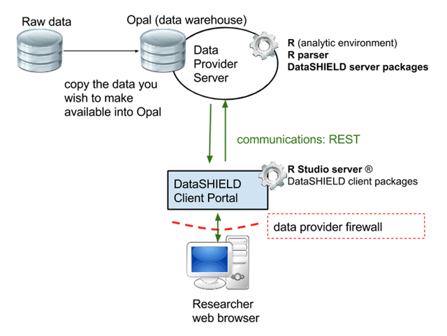

Figure 1: Single Server DataSHIELD Architecture (Wilson et al 2017)

# 2 Setup

## 2.1 Required Opal server with resources

Resources are datasets or computation units which location is described by a URL and access is protected by credentials. When assigned to a R/DataSHIELD server session, remote big/complex datasets or high performance computers are made accessible to data analysts.

Instead of storing the data in Opal’s database, only the way to access them is to be defined: the datasets are kept in their original format and location (an R object, a SQL database, a SPSS file, etc.) and are read directly from the R/DataSHIELD server-side session. Then as soon as there is a R reader for the dataset or a connector for the analysis services, a resource can be defined. Opal takes care of the DataSHIELD permissions (a DS user cannot see the resource’s credentials) and of the resources assignment to a R/DataSHIELD session (see Figure )

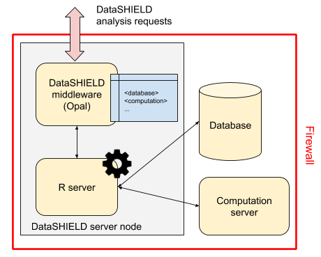

Figure 2: Resources: a new DataSHIELD infrastructure

The `resourcer` R package allows to deal with the main data sources (using tidyverse, DBI, dplyr, sparklyr, MongoDB, AWS S3, SSH etc.) and is easily extensible to new ones including specific data infrastructure in R or Bioconductor. So far `ExpressionSet`files are accesible through the `resourcer` package. The `dsOmics` package contains a new extension that deals with VCF (Variant Calling Format) files which are coerced to a GDS (Genomic Data Storage) format (VCF2GDS).

We have prepared a test environment, with the Opal implementation of Resources and an appropriate R/DataSHIELD configuration that is available at: https://opal-test.obiba.org. This figure illustrate the resources which are avaiable for the `test` project:

[figure not shown]

Figure 3: Resources from a test enviroment available at https://opal-test.obiba.org

It is possible to declare a resource that is to be resolved by an R package that uses the `resourcer` API

[figure not shown]

Figure 4: Declaration of a resource corresponding to a VCF2GDS format

This can be automatically be done using R code by:

```r
devtools::install_github("obiba/opalr", dependencies = TRUE)
```

```r
> library(opalr)
> o <- opal.login(username = "XXXXX", password = "XXXXX",
                  url = "https://opal-test.obiba.org")
> opal.assign.resource(o, "D", value = "test.example.vcf")
> opal.execute(o, "class(D)")
[1] "GDSFileResourceClient" "FileResourceClient"    "ResourceClient"        "R6"
> opal.assign.script(o, "G", quote(D$getValue()))
> opal.execute(o, "class(G)")
[1] "gds.class"
> opal.execute(o, "gdsfmt::diagnosis.gds(G)")
$stream
   id size capacity num_chunk                    path
1   1  422      422         1                / $head$
2   2  113      113         1        sample.id $head$
3   3  149      149         1        sample.id $data$
4   4  114      114         1           snp.id $head$
5   5  397      397         1           snp.id $data$
6   6  113      113         1        snp.rs.id $head$
7   7 1757     1757         1        snp.rs.id $data$
8   8  114      114         1     snp.position $head$
9   9  793      793         1     snp.position $data$
10 10  113      113         1   snp.chromosome $head$
11 11   97       97         1   snp.chromosome $data$
12 12  113      113         1       snp.allele $head$
13 13  417      417         1       snp.allele $data$
14 16  115      115         1        snp.annot $head$
15 17  115      115         1   snp.annot/qual $head$
16 18  105      105         1   snp.annot/qual $data$
17 19  113      113         1 snp.annot/filter $head$
18 20  149      149         1 snp.annot/filter $data$
19 21   81       81         1         genotype $head$
20 22 2850     2850         1         genotype $data$
21 NA    0        0         0                $unused$

$log
 [1] "Open a GDS file (File Version, major: 01, minor: 00)."         "Load all data stream (20 in total) with an entry id (0x0001)."
 [3] "Load the root folder from the entry (size: 422)."              "==> / []"
 [5] "==> / [dStr8]"                                                 "==> / [dInt32]"
 [7] "==> / [dStr8]"                                                 "==> / [dInt32]"
 [9] "==> / [dStr8]"                                                 "==> / [dStr8]"
[11] "==> / [dBit2]"                                                 "==> snp.annot []"
[13] "==> / [dFloat32]"                                              "==> / [dStr8]"

> opal.logout(o)
```

## 2.2 Required DataSHIELD packages in the opal server

Required DataSHIELD packages must be uploaded in the opal server through the Administration site by accessing to DataSHIELD tab. In our case, both `dsBase` and `dsOmics` packages must be installed as is illustrated in the figure.

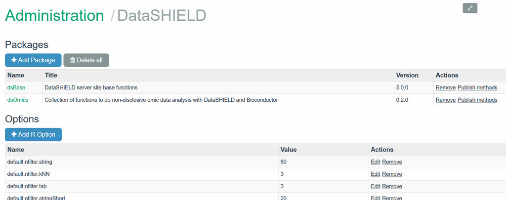

Figure 5: Installed packages in the test opal server

The tab **+Add package** ca be used to install a new package. The figure depicts how `dsOmics` was intalled into the opal server

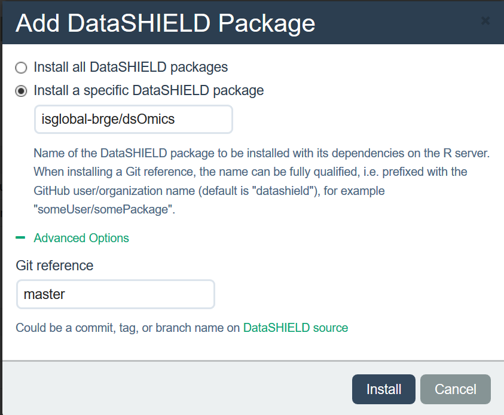

Figure 6: Description how `dsOmics` package was intalled into the test opal server

## 2.3 Required R Packages in the client site (e.g. local machine)

In order to use the functions contained within this package the following R packages must be installed and loaded.

```r
library(resourcer)
library(DSI)
library(DSOpal)
library(dsBaseClient)
library(dsOmics)
```

**Notes**:

- `dsOmics` depends on the `resourcer` package that can be installed by:

```r
devtools::install_github("obiba/resourcer", dependencies = TRUE)
```

```r
devtools::install_github("datashield/DSI", dependencies = TRUE)
devtools::install_github("datashield/DSOpal", dependencies = TRUE)
devtools::install_github("datashield/dsBaseClient", dependencies = TRUE)
devtools::install_github("isglobal-brge/dsOmics", dependencies = TRUE)
```

# 3 Omics data analysis

# 4 Analysis of methylation data from an `ExpressionSet`

Here we illustrate how to analyze methylation data stored as an `ExpressionSet`. Figure shows that our test opal server contains two data sets (GSE80970.Rdata and GSE66351.Rdata) having information on DNA methylation profiling. Both are R data files containing an object of `ExpressionSet` class. Data corresponds to CpGs beta values measured in the superior temporal gyrus and prefrontal cortex brain regions of patients with Alzheimer’s. These data have been downloaded from GEO (https://www.ncbi.nlm.nih.gov/geo/) using the GEO accession numbers GSE80970 and GSE66351, respectively. Researchers who are not familiar with `ExpressionSet`s or for those who have data in other formats, this page (https://kasperdanielhansen.github.io/genbioconductor/html/ExpressionSet.html) can be used as a good starting point to undersatand how methylation data can be encapsulated in a `ExpressionSet`.

First, we start by login and asigning resources to DataSHIELD

```r
builder <- DSI::newDSLoginBuilder()
builder$append(server = "study1", url = "https://opal-test.obiba.org",
               user = "dsuser", password = "password",
               resource = "test.GSE66351", driver = "OpalDriver")
builder$append(server = "study2", url = "https://opal-test.obiba.org",
               user = "dsuser", password = "password",
               resource = "test.GSE80970", driver = "OpalDriver")

logindata <- builder$build()

conns <- DSI::datashield.login(logins = logindata, assign = TRUE,
                               symbol = "res")
```

After that, we check whether the opal server has the assigned resources. This can be performed by using a function from `dsBaseClient` package.

```r
ds.ls()
```

```
$study1
[1] "res"

$study2
[1] "res"
```

The `ExpressionSet` object (accessed by the resource client) could be coerced to a data frame by

```r
datashield.assign.expr(conns, symbol = "methyl_df",
                       expr = quote(as.resource.data.frame(res)))
ds.class("methyl_df")
```

```
$study1
[1] "data.frame"

$study2
[1] "data.frame"
```

The coercion creates a data frame with CpGs and covariables in columns. We do not recomment to work with data frames for omic data since Bioconductor has efficient classes to deal with this type of data. We just illustrate that this coercion is possible and then DataSHIELD functions can be used to perform different statistical analyses. For instance, a data frame can be inspected, using `dsBaseClient` functions

```r
ds.summary("methyl_df$casecon")
```

```
$study1
$study1$class
[1] "character"

$study1$length
[1] 190


$study2
$study2$class
[1] "character"

$study2$length
[1] 286
```

```r
ds.summary("methyl_df$cg21477232")
```

```
$study1
$study1$class
[1] "numeric"

$study1$length
[1] 190

$study1$`quantiles & mean`
       5%       10%       25%       50%       75%       90%       95%
0.6068475 0.6271410 0.6560050 0.6942150 0.7294200 0.7471330 0.7648265
     Mean
0.6911465


$study2
$study2$class
[1] "numeric"

$study2$length
[1] 286

$study2$`quantiles & mean`
       5%       10%       25%       50%       75%       90%       95%
0.6070325 0.6277050 0.6550325 0.6918900 0.7163225 0.7363900 0.7499450
     Mean
0.6857195
```

Another example is that we can fit a glm model in the multiple studies using an approach that is similar to analyze pooled data

```r
ds.glm(cg21477232 ~ casecon + Sex, data="methyl_df",
       family="binomial")
```

```
$Nvalid
[1] 476

$Nmissing
[1] 0

$Ntotal
[1] 476

$disclosure.risk
       RISK OF DISCLOSURE
study1                  0
study2                  0

$errorMessage
       ERROR MESSAGES
study1 "No errors"
study2 "No errors"

$nsubs
[1] 476

$iter
[1] 5

$family

Family: binomial
Link function: logit


$formula
[1] "cg21477232 ~ casecon + Sex"

$coefficients
                Estimate Std. Error     z-value      p-value low0.95CI.LP
(Intercept)  0.763407651  0.1492729  5.11417299 3.151185e-07    0.4708381
caseconCTRL -0.003035308  0.2034611 -0.01491837 9.880973e-01   -0.4018118
SexM         0.068800282  0.2065240  0.33313461 7.390327e-01   -0.3359793
            high0.95CI.LP      P_OR low0.95CI.P_OR high0.95CI.P_OR
(Intercept)     1.0559772 0.6820931      0.6155821        0.741921
caseconCTRL     0.3957412 0.9969693      0.6691066        1.485485
SexM            0.4735798 1.0712222      0.7146379        1.605732

$dev
[1] 4.843834

$df
[1] 473

$output.information
[1] "SEE TOP OF OUTPUT FOR INFORMATION ON MISSING DATA AND ERROR MESSAGES"
```

As previously mention it is prefered to directly extract the R object as Bioconductor’s `ExpressionSet`. This can be performed since DataSHIELD configuration allows `as.resource.object()` assignment function.

```r
datashield.assign.expr(conns, symbol = "methy",
                       expr = quote(as.resource.object(res)))
ds.class("methy")
```

```
$study1
[1] "ExpressionSet"
attr(,"package")
[1] "Biobase"

$study2
[1] "ExpressionSet"
attr(,"package")
[1] "Biobase"
```

Then, some Bioconductor-type functions can be use to get non-disclosive information of `ExpressionSet`s at each server from the client using similar functions as those defined in `dsBaseClient`. For example, feature names can be seen by

```r
fn <- ds.featureNames("methy")
lapply(fn, head)
```

```
$study1
[1] "cg21477232" "cg15065877" "cg22631350" "cg13376768" "cg21915026"
[6] "cg23203918"

$study2
[1] "cg21477232" "cg15065877" "cg22631350" "cg13376768" "cg21915026"
[6] "cg23203918"
```

Experimental phenotypes variables can be obtained by

```r
ds.varLabels("methy")
```

```
$study1
 [1] "title"                   "geo_accession"
 [3] "status"                  "submission_date"
 [5] "last_update_date"        "type"
 [7] "channel_count"           "source_name_ch1"
 [9] "organism_ch1"            "characteristics_ch1"
[11] "characteristics_ch1.1"   "characteristics_ch1.2"
[13] "characteristics_ch1.3"   "characteristics_ch1.4"
[15] "characteristics_ch1.5"   "characteristics_ch1.6"
[17] "characteristics_ch1.7"   "characteristics_ch1.8"
[19] "molecule_ch1"            "extract_protocol_ch1"
[21] "label_ch1"               "label_protocol_ch1"
[23] "taxid_ch1"               "hyb_protocol"
[25] "scan_protocol"           "description"
[27] "data_processing"         "platform_id"
```

[output cut: 39 more lines]